# Aplicações da espectroscopia no NIR no Setor Florestal

Fernanda M.G. Ramalho e Rodrigo Simetti

26/11/2021

## Utilizando o R

Instruções de uso e instalação

## Pacotes utilizados

Para a construção dos modelos vamos utilizar os pacotes *mdatools* e *tidyverse*.

- O [*mdatools*](https://mdatools.com/) será o responsavel pela parte de quimiometria, disponibilizando as funções para análise multivariada e pré-processamento dos dados.
- O [*tidyverse*](https://www.tidyverse.org/) é uma familia de pacotes do [*R*](https://cran.r-project.org/) que usaremos para leitura e manipulação dos dados, além da elaboração de algumas figuras.

Caso não tenha os pacotes instalados, utilize os comandos abaixo:

```r
install.packages("mdatools", dependencies = TRUE)
install.packages("tidyverse", dependencies = TRUE)
```

```r
library(mdatools)
library(tidyverse)
```

## Dados 11 espécies florestais

```r
da_especies <-
  readxl::read_xlsx(path = "Unicentro_NIR x 11 espécies.xlsx",
                    sheet = "NIR x 11 especies",
                    range = "B1:BHB395")
```

```r
X <-
  da_especies %>%
  filter(Face == "rd") %>%
  select(7:1561)

Y_r <-
  da_especies %>%
  filter(Face == "rd") %>%
  select(Densidade)

Y_rc <-
  da_especies %>%
  filter(Face == "rd") %>%
  select(Esp)
```

```r
comprimento_de_onda  <- substring(colnames(X),
                                  first = 1,
                                  last = 6)

comprimento_de_onda <- as.numeric(comprimento_de_onda)
```

```r
espectro_medio_esp <-
  da_especies %>%
  filter(Face == "rd") %>%
  select(Esp, 7:1561) %>%
  group_by(Esp) %>%
  summarise_all(mean)
```

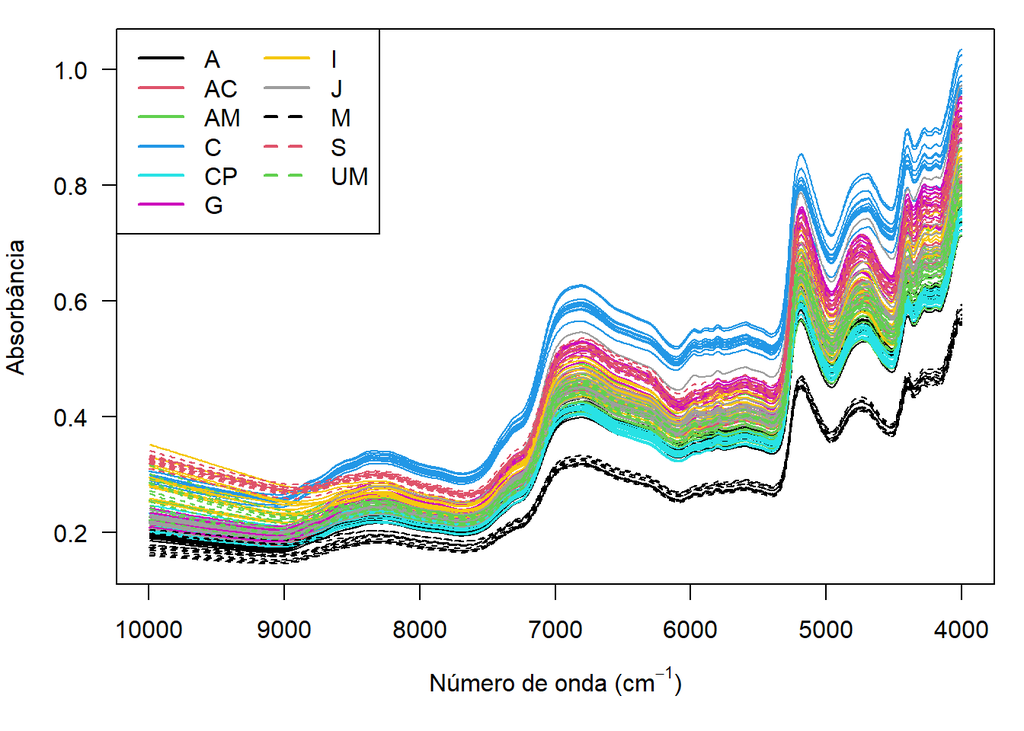

```r
par(mar = c(5, 4, 1, 1))
matplot(comprimento_de_onda,
        t(X),
        type = "l",
        lty = rep(1:2, each = 8)[as.factor(Y_rc$Esp)],
        xlab = expression("Número de onda (cm"^-1*")"),
        ylab = "Absorbância",
        las = 1,
        xlim = rev(range(comprimento_de_onda)),
        col = as.factor(Y_rc$Esp)
        )
legend("topleft",
       legend = as.factor(espectro_medio_esp$Esp),
       col = as.factor(espectro_medio_esp$Esp),
       lty = rep(1:2, each = 8),
       lwd = 2,
       ncol = 2)
```

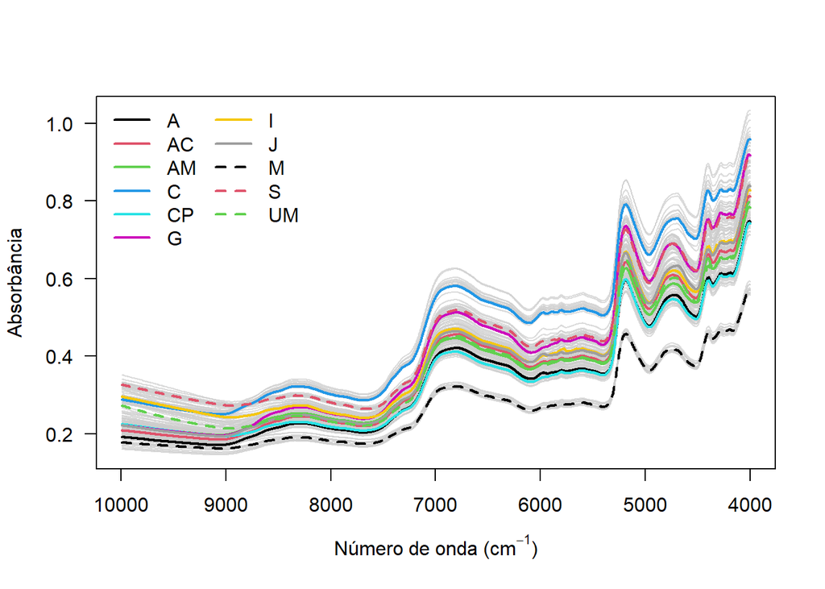

```r
matplot(comprimento_de_onda,
        t(X),
        type = "l",
        lty = 1,
        xlab = expression("Número de onda (cm"^-1*")"),
        ylab = "Absorbância",
        las = 1,
        xlim = rev(range(comprimento_de_onda)),
        col = alpha("grey80", .7))

matlines(comprimento_de_onda,
         t(espectro_medio_esp[ , -1]),
         type = "l",
         lty = rep(1:2, each = 8),
         lwd = 2,
         col = as.factor(espectro_medio_esp$Esp)
         )
legend("topleft",
       legend = as.factor(espectro_medio_esp$Esp),
       col = as.factor(espectro_medio_esp$Esp),
       lty = rep(1:2, each = 8),
       lwd = 2,
       ncol = 2, bty = "n")
```

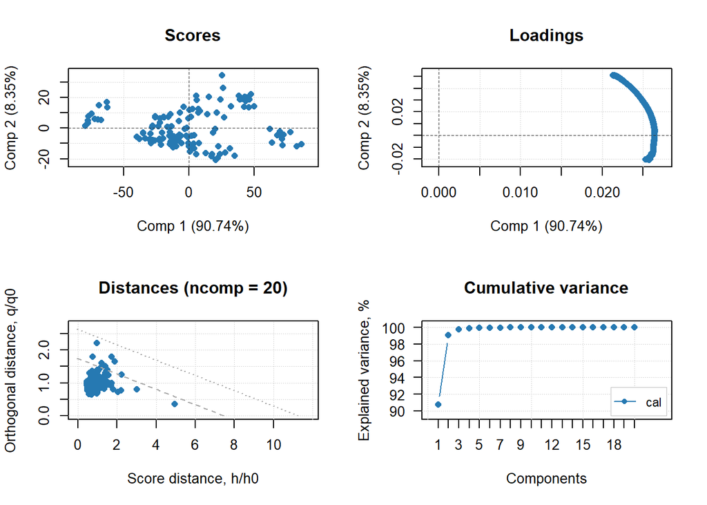

```r
pca_especies <- pca(x = X, center = T, scale = T)
plot(pca_especies)
```

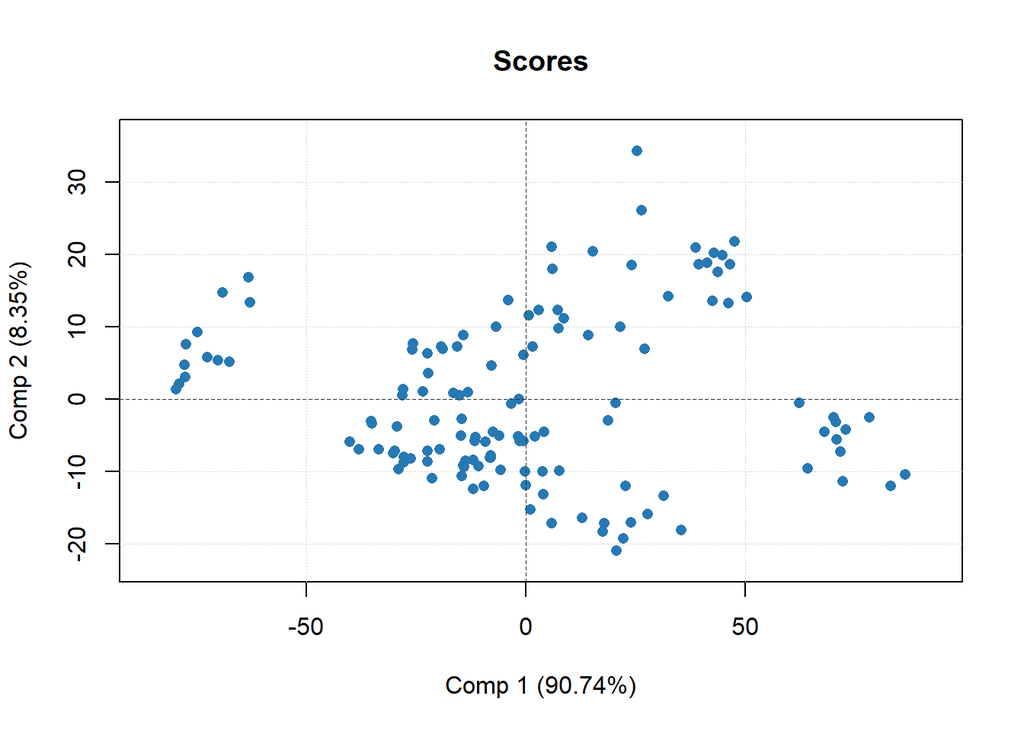

```r
plotScores(pca_especies)
```

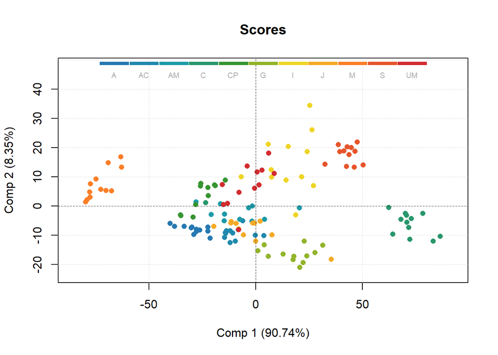

```r
plotScores(pca_especies, cgroup = factor(Y_rc$Esp))
```

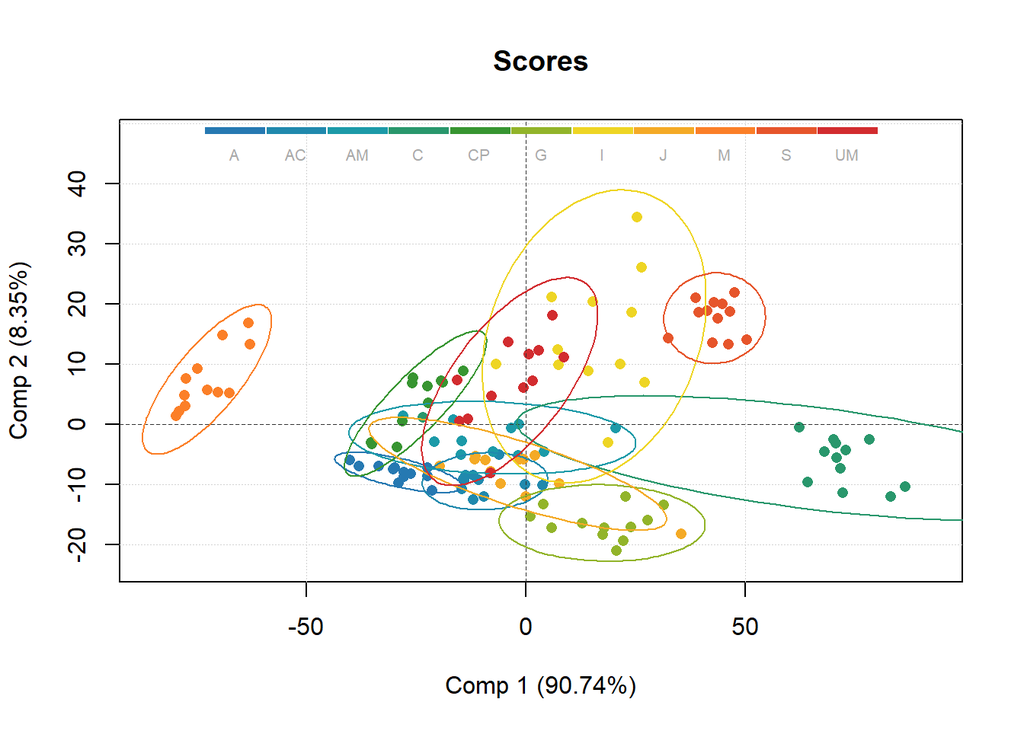

```r
plotConfidenceEllipse(plotScores(pca_especies, cgroup = factor(Y_rc$Esp)))
```

```r
m1_r <- pls(x = X,
            y = Y_r,
            ncomp = 15,
            center = T,
            scale = T,
            cv = 1)
summary(m1_r)
```

```
##
## PLS model (class pls) summary
## -------------------------------
## Info:
## Number of selected components: 15
## Cross-validation: full (leave one out)
##
## Response variable: Densidade
##     X cumexpvar Y cumexpvar    R2   RMSE Slope    Bias  RPD
## Cal    99.99741    95.30913 0.953 45.802 0.953  0.0000 4.63
## Cv           NA          NA 0.896 68.192 0.924 -1.3912 3.11
```

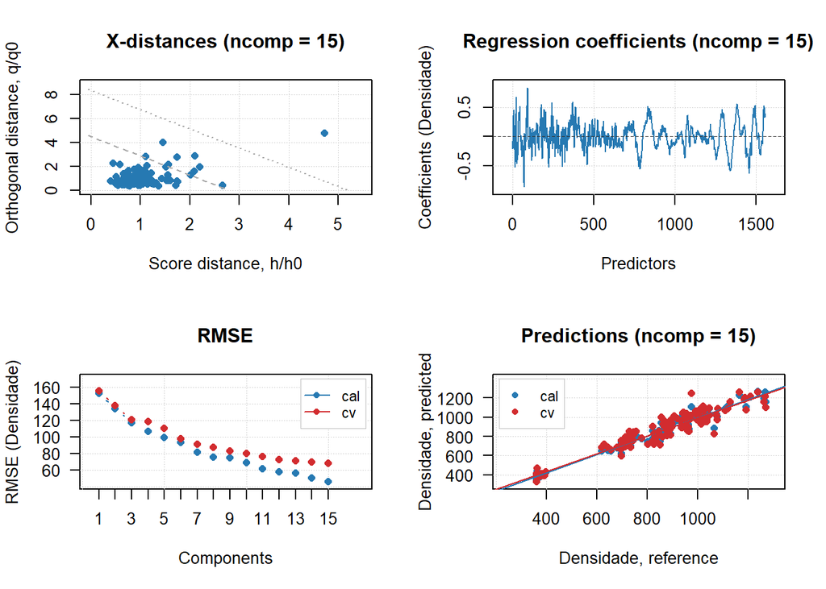

```r
plot(m1_r)
```

```r
m2_r <- pls(x = X[ , seq(1, 1555, by = 5)],
            y = Y_r,
            ncomp = 15,
            center = T,
            scale = T,
            cv = 1)
summary(m2_r)
```

```
##
## PLS model (class pls) summary
## -------------------------------
## Info:
## Number of selected components: 15
## Cross-validation: full (leave one out)
##
## Response variable: Densidade
##     X cumexpvar Y cumexpvar    R2   RMSE Slope    Bias  RPD
## Cal    99.99735    95.44547 0.954 45.132 0.954  0.0000 4.70
## Cv           NA          NA 0.898 67.675 0.925 -1.6945 3.14
```

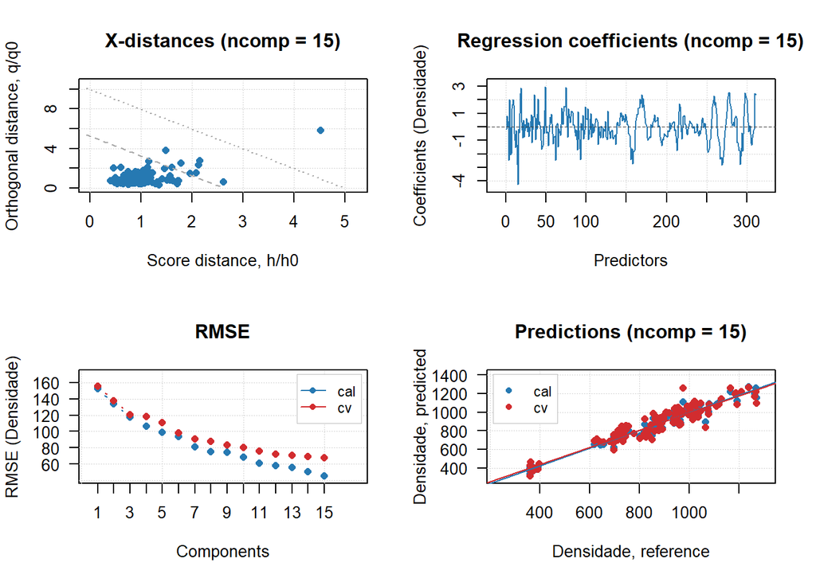

```r
plot(m2_r)
```

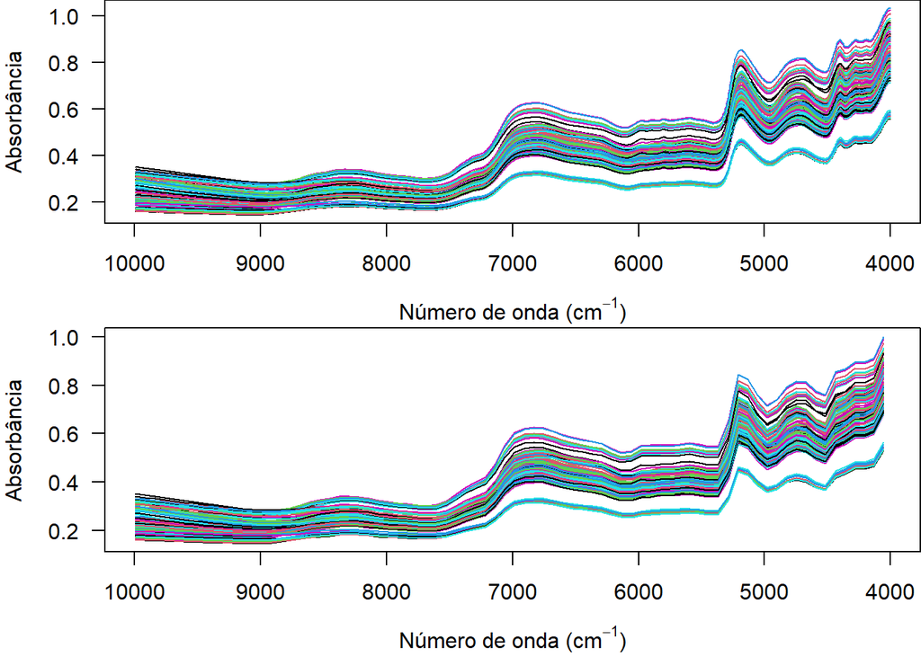

```r
par(mfrow = c(2,1), mar = c(4, 4, 0, 0))
matplot(comprimento_de_onda,
        t(X),
        type = "l",
        lty = 1,
        xlab = expression("Número de onda (cm"^-1*")"),
        ylab = "Absorbância",
        las = 1,
        xlim = rev(range(comprimento_de_onda)))


matplot(comprimento_de_onda[seq(1, 1555, by = 20)],
        t(X[ , seq(1, 1555, by = 20)]),
        type = "l",
        lty = 1,
        xlab = expression("Número de onda (cm"^-1*")"),
        ylab = "Absorbância",
        las = 1,
        xlim = rev(range(comprimento_de_onda)))
```

```r
Y_test <-
  da_especies %>%
  filter(Face == "tv") %>%
  select(Densidade)

X_test <-
  da_especies %>%
  filter(Face == "tv") %>%
  select(7:1561)
```

```r
teste <- predict(m2_r,
                 X_test[ , seq(1, 1555, by = 5)],
                 Y_test)
summary(teste)
```

```
##
## PLS regression results (class plsres) summary
## Info:
## Number of selected components: 15
##
## Response variable Densidade:
##         X expvar X cumexpvar Y expvar Y cumexpvar      R2    RMSE Slope
## Comp 1    95.835      95.835   69.966      69.966  -2.510 394.721 0.837
## Comp 2     2.743      98.577    4.921      74.887  -1.935 360.938 1.011
## Comp 3     1.262      99.839   15.507      90.395  -0.123 223.225 1.071
## Comp 4     0.025      99.865  -25.337      65.057  -3.084 425.760 1.237
## Comp 5     0.079      99.944  -14.622      50.435  -4.793 507.075 1.217
## Comp 6     0.001      99.945   -2.335      48.100  -5.066 518.882 1.234
## Comp 7     0.002      99.947   -9.298      38.802  -6.153 563.448 1.327
## Comp 8     0.008      99.955  -11.492      27.310  -7.496 614.079 1.422
## Comp 9     0.010      99.964   -7.610      19.700  -8.386 645.422 1.462
## Comp 10    0.025      99.990  -35.209     -15.509 -12.501 774.095 1.619
## Comp 11    0.002      99.992   22.326       6.818  -9.891 695.270 1.681
## Comp 12    0.001      99.992    3.567      10.384  -9.475 681.835 1.634
## Comp 13    0.001      99.993   10.580      20.964  -8.238 640.324 1.616
## Comp 14    0.001      99.995   29.169      50.133  -4.829 508.621 1.431
## Comp 15   -0.001      99.994    7.285      57.418  -3.977 470.001 1.368
##              Bias  RPD
## Comp 1  -359.1112 1.29
## Comp 2  -336.1744 1.61
## Comp 3  -144.8146 1.24
## Comp 4  -382.2802 1.13
## Comp 5  -473.4137 1.16
## Comp 6  -485.1685 1.15
## Comp 7  -512.7119 0.91
## Comp 8  -549.8184 0.77
## Comp 9  -580.4228 0.75
## Comp 10 -721.1505 0.75
## Comp 11 -640.0582 0.78
## Comp 12 -626.8888 0.79
## Comp 13 -588.4359 0.84
## Comp 14 -471.0204 1.10
## Comp 15 -440.5188 1.29
```

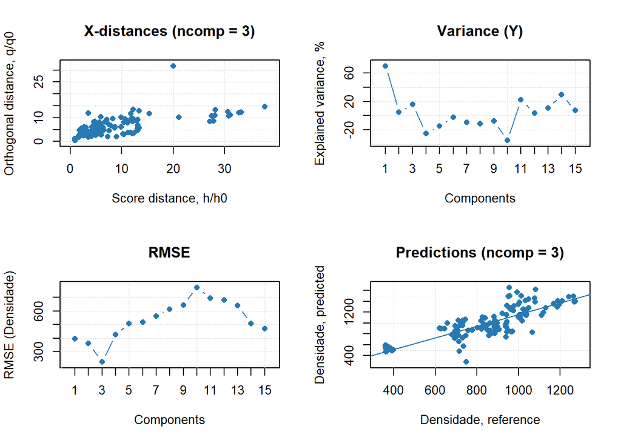

```r
plot(teste, ncomp = 3)
```

```r
X_c <-
  da_especies %>%
  filter(Face == "tv") %>%
  filter(Esp == "I" | Esp == "UM" | Esp == "G" ) %>%
  select(7:1561)


Y_c <-
  da_especies %>%
  filter(Face == "tv") %>%
  filter(Esp == "I" | Esp == "UM" | Esp == "G") %>%
  select(Esp)
```

```r
m1_c <- plsda(x = X_c[ , seq(1, 1555, by = 5)],
              c = as.factor(Y_c$Esp),
              center = T,
              scale = T,
              ncomp = 15,
              cv = 1)
summary(m1_c)
```

```
##
## PLS-DA model (class plsda) summary
## ------------------------------------
## Info:
## Number of selected components: 2
## Cross-validation: full (leave one out)
##
## Class #1 (G)
##     X cumexpvar Y cumexpvar TP FP TN FN Spec. Sens. Accuracy
## Cal       96.88       58.73 12  1 23  0 0.958     1    0.972
## Cv           NA          NA 12  1 23  0 0.958     1    0.972
##
## Class #2 (I)
##     X cumexpvar Y cumexpvar TP FP TN FN Spec. Sens. Accuracy
## Cal       96.88       58.73 11  1 23  1 0.958 0.917    0.944
## Cv           NA          NA 11  1 23  1 0.958 0.917    0.944
##
## Class #3 (UM)
##     X cumexpvar Y cumexpvar TP FP TN FN Spec. Sens. Accuracy
## Cal       96.88       58.73  8  1 23  4 0.958 0.667    0.861
## Cv           NA          NA  8  1 23  4 0.958 0.667    0.861
```

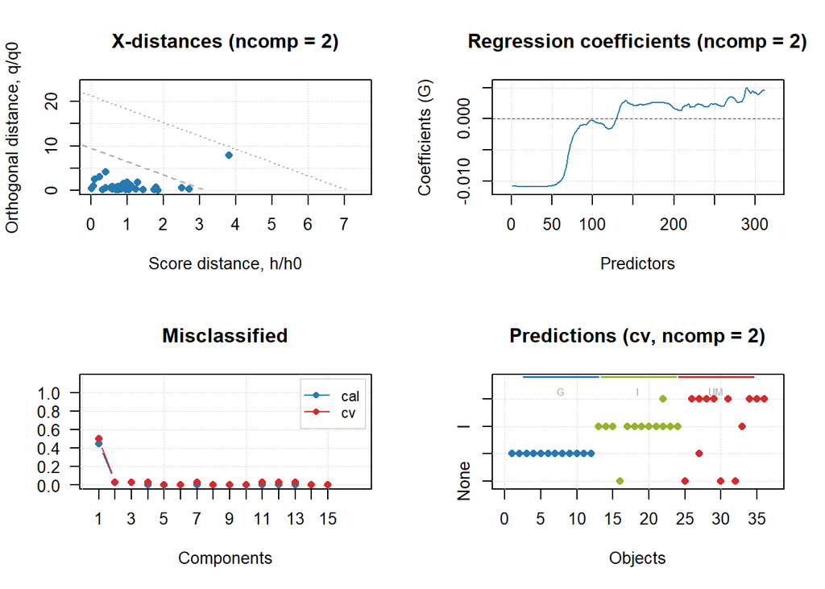

```r
plot(m1_c)
```

```r
getConfusionMatrix(m1_c$calres)
```

```
##     G  I UM None
## G  12  0  0    0
## I   0 11  1    1
## UM  1  1  8    3
```

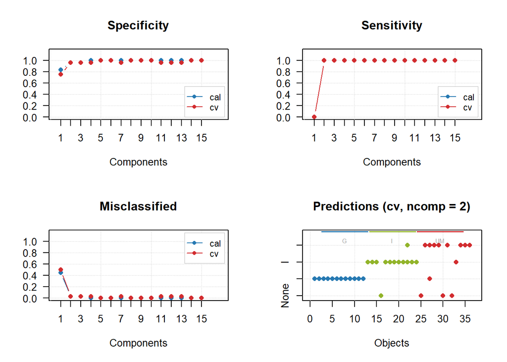

```r
par(mfrow = c(2, 2))
plotSpecificity(m1_c)
plotSensitivity(m1_c)
plotMisclassified(m1_c)
plotPredictions(m1_c)
```

```r
par(mfrow = c(1, 1))
```

## Dados de fertilidade do solo (Munawar et al, 2020)

Os dados neste exemplo são provenientes de um estudo de fertilidade do solo realizado na Indonésia. Os dados e a descrição do experimento estão disponíveis em [*“Calibration models database of near infrared spectroscopy to predict agricultural soil fertility properties”*](https://www.sciencedirect.com/science/article/pii/S2352340920303632#bib0001). É necessário fazer o download do arquivo e colocar na pasta de trabalho do R.

```r
da_solo <-
  readxl::read_xlsx(path = "NIR spectra Data of Soil samples and fertility properties as matrix X and Y.xlsx",
                    sheet = "Data Matrix X and Y")
```

O *data frame* utilizado contem o número da amostra, os dados espectrais e as informação das análises de refência do solo. Vamos separar os dados espectrais e os dados de referência nos objetos *X* e *Y*, respectivamente.

```r
X <-
  da_solo %>% select(2:1558)

Y <-
  da_solo %>% select(`K (cmol/kg)`:`N content (%)`)
```

### Inspeção visual dos espectros

Vamos criar um vetor com os nomes dos espectros, neste banco de dados os nomes já estão corretos, mas é necessário ficar atento com isso, pois algumas vezes simbolos indesejados estão presentes.

```r
comprimento_de_onda  <- substring(colnames(X),
                                  first = 1,                                    last = 6)

comprimento_de_onda <- as.numeric(comprimento_de_onda)
```

Repare que na elaboração da figura foi necessário transpor o banco de dados dos espectros.

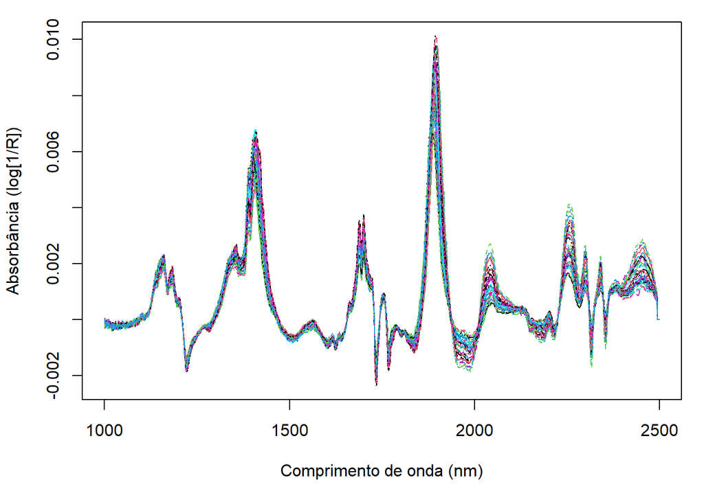

```r
par(mar = c(5,4,1,1) + 0.1)
matplot(comprimento_de_onda,
        t(X),
        type = "l",
        xlab = "Comprimento de onda (nm)",
        ylab = "Absorbância (log[1/R])",
        font.lab = 1)
```

```r
# abline(v =  1410, lty = "dashed")
# abline(v =  1895, lty = 2)
# rect(xleft = 1100,
#      ybottom = -2,
#      xright = 1225,
#      ytop = 0.2,
#      lty = "blank",
#      col = alpha("grey", 0.5))
```

### Análise de Componentes Principais (*PCA*)

```r
pca_solo <-
  pca(X,
      scale = FALSE,
      center = TRUE,
      info = "PCA - Solos")

summary(pca_solo$calres)
```

```
##
## Summary for PCA results
##
## Selected components: 20
##
##         Expvar Cumexpvar
## Comp 1   66.86     66.86
## Comp 2   25.61     92.47
## Comp 3    5.10     97.57
## Comp 4    0.80     98.37
## Comp 5    0.35     98.72
## Comp 6    0.25     98.97
## Comp 7    0.11     99.08
## Comp 8    0.08     99.16
## Comp 9    0.07     99.23
## Comp 10   0.05     99.28
## Comp 11   0.05     99.33
## Comp 12   0.05     99.38
## Comp 13   0.04     99.42
## Comp 14   0.04     99.46
## Comp 15   0.04     99.50
## Comp 16   0.04     99.53
## Comp 17   0.03     99.57
## Comp 18   0.03     99.60
## Comp 19   0.03     99.63
## Comp 20   0.03     99.66
```

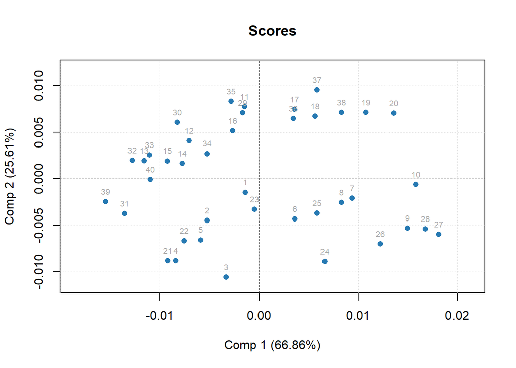

```r
plotScores(pca_solo$calres,
           show.labels = TRUE)
```

### Análise descritiva

```r
da_descritiva <-
  Y %>%
  summarise_all(list("Minimo" = min,
                     "Máximo" = max,
                     "Média" = mean,
                     "Desvio padrão" = sd,
                     "Variância" = var)) %>%
  pivot_longer(everything(),
               names_to = c("Variavel", "Estatistica"),
               names_sep="_") %>%
  pivot_wider(names_from = Variavel)

da_descritiva[,-1] <- round(da_descritiva[,-1], 2)

rmarkdown::paged_table(da_descritiva)
```

| Estatistica | K (cmol/kg) | Mg (cmol/kg) | Ca (cmol/kg) | P (ppm) | pH (KCl) | N content (%) |
| --- | --- | --- | --- | --- | --- | --- |
| Minimo | 0.26 | 0.31 | 0.39 | 1.68 | 2.57 | 0.02 |
| Máximo | 2.58 | 18.07 | 20.18 | 40.92 | 11.21 | 0.52 |
| Média | 0.88 | 6.43 | 7.45 | 14.49 | 5.78 | 0.15 |
| Desvio padrão | 0.51 | 4.75 | 6.41 | 11.46 | 2.21 | 0.14 |
| Variância | 0.26 | 22.60 | 41.08 | 131.26 | 4.89 | 0.02 |

## Densidade da Madeira (costa et al, 2018)

```r
nir_url <- 'https://raw.githubusercontent.com/Rsimetti/cursoAP2020/master/Wood_density.csv'
nir_madeira <- read.csv(url(nir_url),
                        header = T,
                        sep = ";",
                        dec = ",")
rm(nir_url)
```

### Inspeção visual dos espectros

```r
num_de_onda <- substring(colnames(nir_madeira[ , c(-1, -435)]), 2, 7)
num_de_onda <- as.numeric(num_de_onda)
```

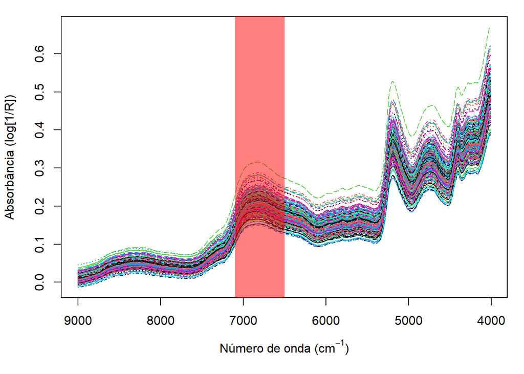

```r
par(mar = c(5,4,1,1) + 0.1)
matplot(num_de_onda,
        t(nir_madeira[ , 2:434]),
        xlim = rev(range(num_de_onda)),
        type = "l",
        xlab = expression("Número de onda (cm"^-1*")"),
        ylab = "Absorbância (log[1/R])",
        # col = alpha(c("#D9EF8B",
        #               "#66BD63")[as.factor(nir_madeira$Material)],
        #             1),
        font.lab = 1)
rect(xleft = 7100,
     ybottom = -2,
     xright = 6500,
     ytop = 2,
     lty = "blank",
     col = alpha("red", 0.5))
```

### Análise descritiva

```r
da_descritiva <-
  nir_madeira[ , 1] %>%
  as_tibble() %>%
  summarise_all(list("Minimo" = min,
                     "Máximo" = max,
                     "Média" = mean,
                     "Desvio padrão" = sd,
                     "Variância" = var)) %>%
  pivot_longer(everything(),
               names_to = "Estatistica",
               values_to = "Valor")

da_descritiva[,-1] <- round(da_descritiva[,-1], 2)

rmarkdown::paged_table(da_descritiva)
```

| Estatistica | Valor |
| --- | --- |
| Minimo | 0.29 |
| Máximo | 0.68 |
| Média | 0.46 |
| Desvio padrão | 0.07 |
| Variância | 0.00 |

```r
pca1 = pca(nir_madeira[ , c(-1, -435)],
           scale = TRUE,
           center = TRUE,
           info = "Componentes principais")
```

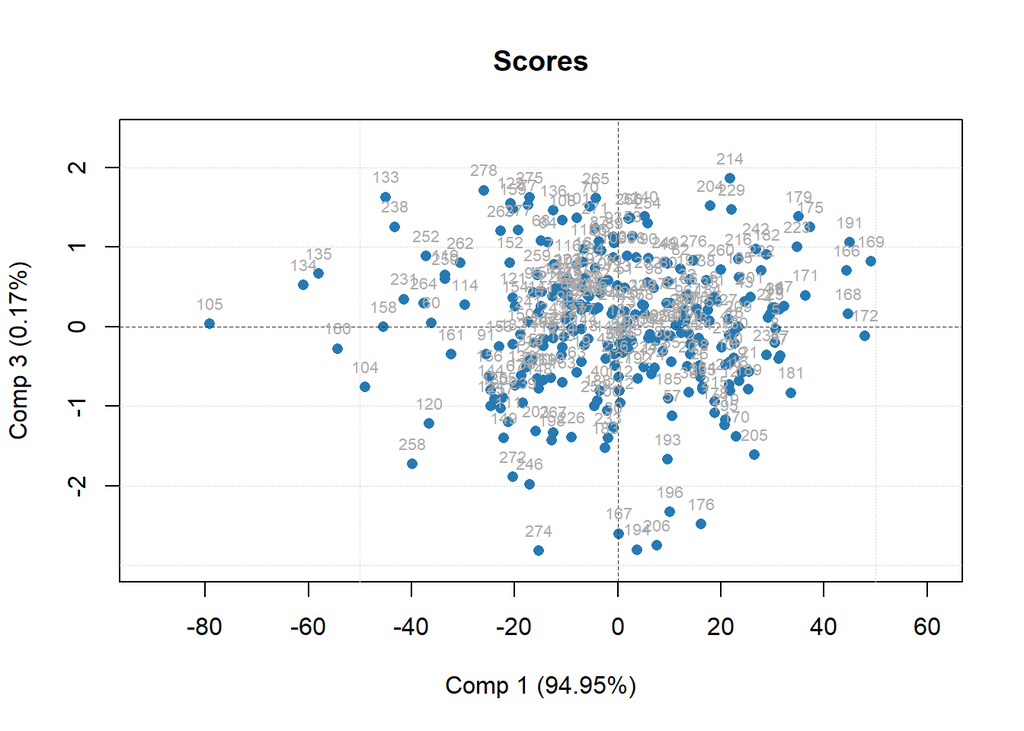

```r
plotScores(pca1, comp = c(1, 3), show.labels = TRUE)
```

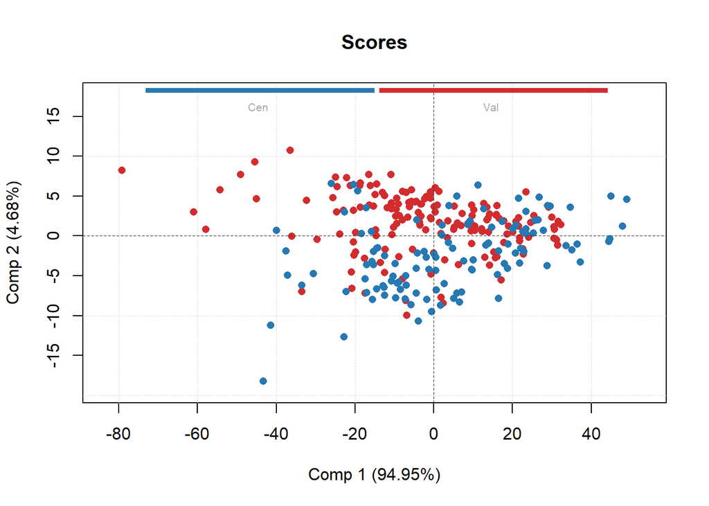

```r
plotScores(pca1$res$cal,
           cgroup = factor(nir_madeira$Material))
```

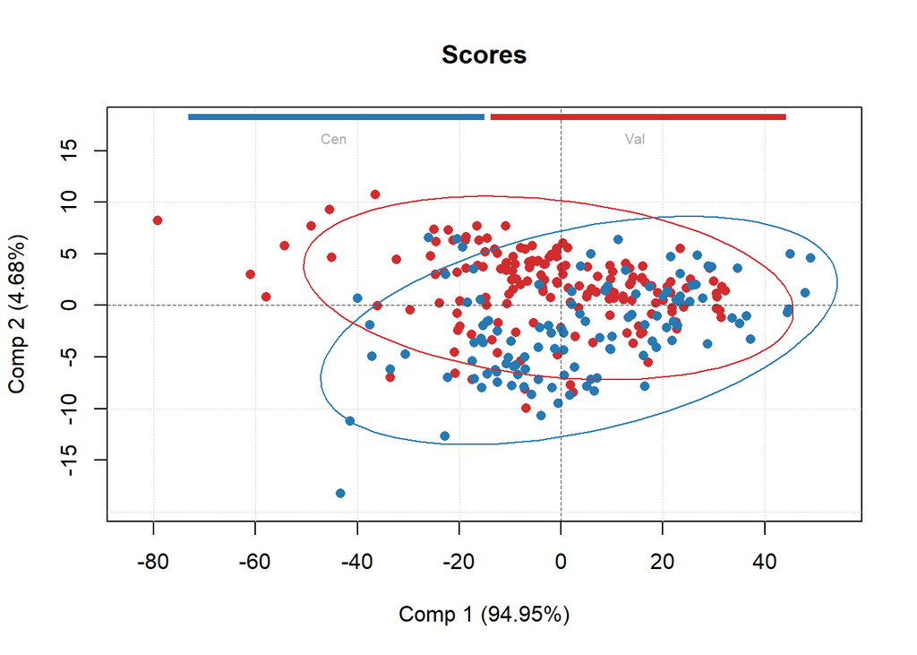

```r
plotConfidenceEllipse(plotScores(pca1$res$cal,
                                 c(1, 2),
                                 cgroup = factor(nir_madeira$Material)))
```

```r
m1_r <-
  pls(x = nir_madeira[ , c(-1, -435)],
      y = nir_madeira$ï..DB,
      ncomp = 20,
      center = T,
      scale = T,
      info = "Modelo geral",
      cv = 1)
```

```r
summary(m1_r)
```

```
##
## PLS model (class pls) summary
## -------------------------------
## Info: Modelo geral
## Number of selected components: 9
## Cross-validation: full (leave one out)
##
##     X cumexpvar Y cumexpvar    R2  RMSE Slope   Bias  RPD
## Cal    99.98664    80.87007 0.809 0.030 0.809  0e+00 2.29
## Cv           NA          NA 0.769 0.033 0.792 -4e-04 2.09
```

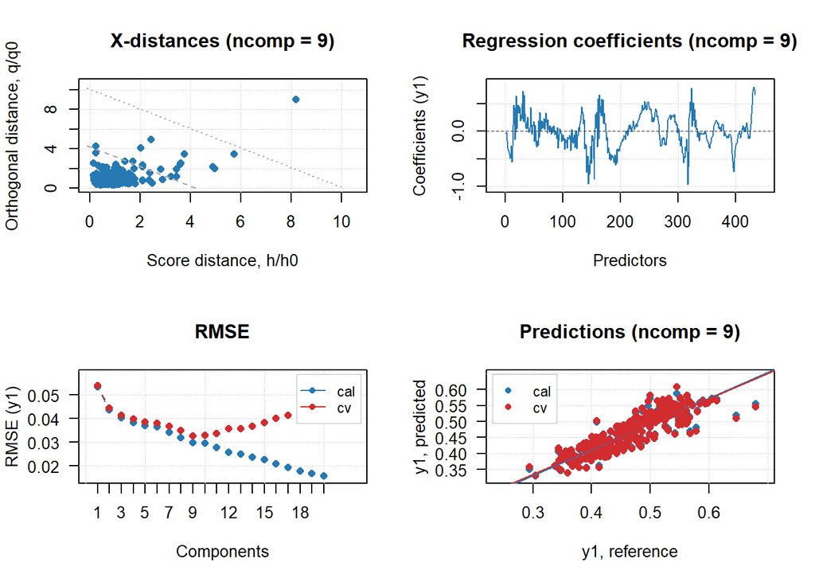

```r
plot(m1_r)
```

```r
X_msc <- prep.msc(as.matrix(nir_madeira[ , c(-1, -435)]))

m2_r_mad <-
  pls(x = X_msc,
      y = nir_madeira$ï..DB,
      ncomp = 20,
      center = T,
      scale = T,
      info = "MSC",
      cv = 1)
summary(m2_r_mad)
```

```
##
## PLS model (class pls) summary
## -------------------------------
## Info: MSC
## Number of selected components: 9
## Cross-validation: full (leave one out)
##
##     X cumexpvar Y cumexpvar    R2  RMSE Slope   Bias  RPD
## Cal    98.33826    78.75441 0.788 0.031 0.788  0e+00 2.17
## Cv           NA          NA 0.742 0.035 0.764 -3e-04 1.97
```

```r
X_1_der <- prep.savgol(as.matrix(nir_madeira[ , c(-1, -435)]),
                       width = 13,
                       porder = 3,
                       dorder = 1)

m2_r_mad <-
  pls(x = X_1_der,
      y = nir_madeira$ï..DB,
      ncomp = 20,
      center = T,
      scale = F,
      info = "1 Derivada",
      cv = 1)
summary(m2_r_mad)
```

```
##
## PLS model (class pls) summary
## -------------------------------
## Info: 1 Derivada
## Number of selected components: 7
## Cross-validation: full (leave one out)
##
##     X cumexpvar Y cumexpvar    R2  RMSE Slope   Bias  RPD
## Cal     98.6896    78.88071 0.789 0.031 0.789  0e+00 2.18
## Cv           NA          NA 0.746 0.034 0.774 -3e-04 1.99
```

```r
idx = seq(2, 278, 5)

Xc = nir_madeira[-idx , c(-1, -435)]
Xt = nir_madeira[idx , c(-1, -435)]

Yc = nir_madeira$ï..DB[-idx]
Yt = nir_madeira$ï..DB[idx]
```

```r
m9_r <-
  pls(x = Xc,
      y = Yc,
      x.test = Xt,
      y.test = Yt,
      ncomp = 20,
      center = T,
      scale = T,
      info = "Modelo geral",
      cv = 1)
```

```r
summary(m9_r)
```

```
##
## PLS model (class pls) summary
## -------------------------------
## Info: Modelo geral
## Number of selected components: 9
## Cross-validation: full (leave one out)
##
##      X cumexpvar Y cumexpvar    R2  RMSE Slope    Bias  RPD
## Cal     99.98839    80.60211 0.806 0.030 0.806  0.0000 2.28
## Cv            NA          NA 0.752 0.034 0.783 -0.0005 2.01
## Test    99.97188    87.02041 0.784 0.030 0.823  0.0011 2.17
```

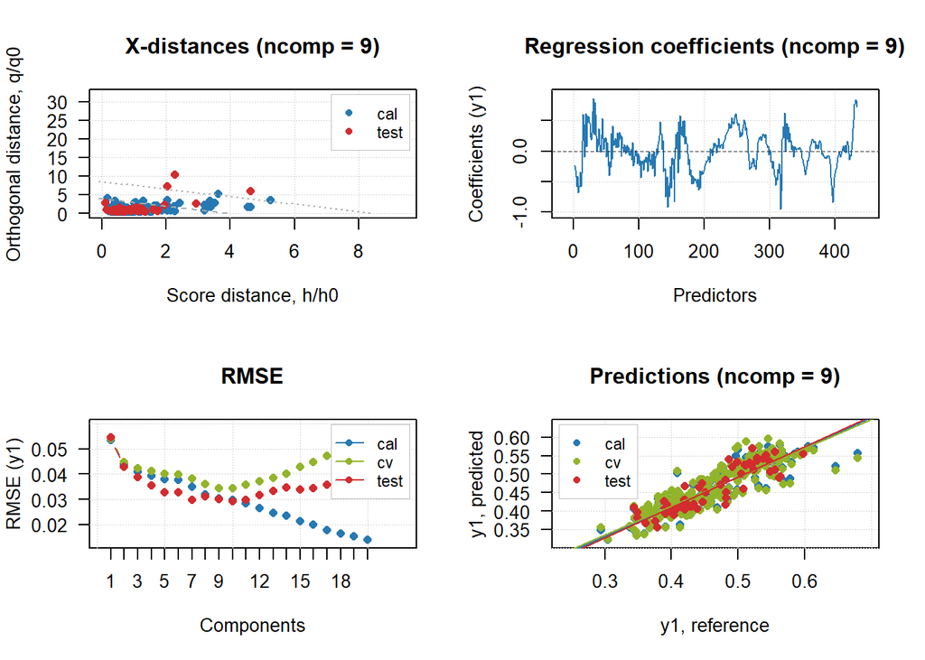

```r
plot(m9_r)
```

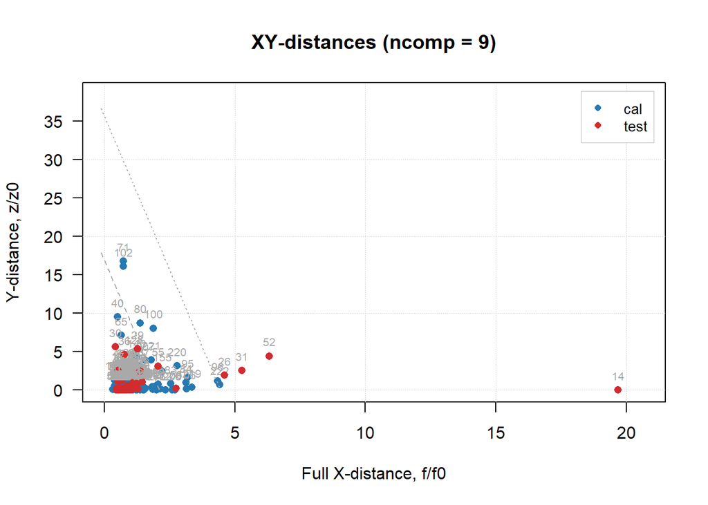

```r
plotXYResiduals(m9_r, show.labels = TRUE, labels = "indices")
```

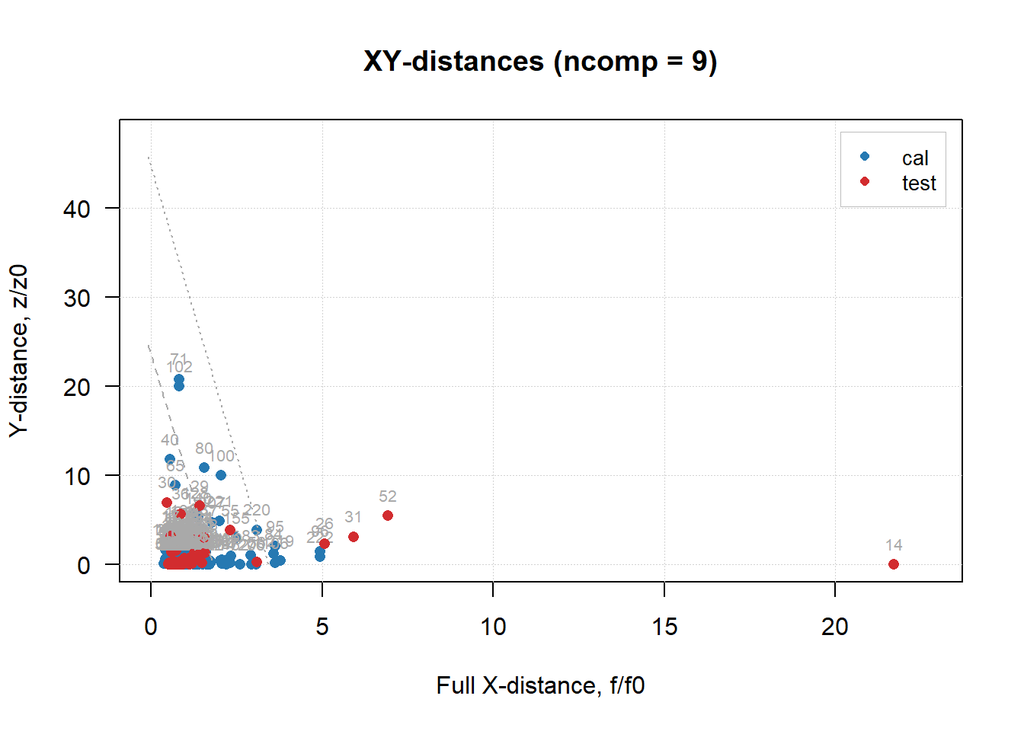

```r
DIST_m9_r = setDistanceLimits(m9_r, lim.type = "ddrobust")
plotXYResiduals(DIST_m9_r, show.labels = TRUE, labels = "indices")
```

```r
c = categorize(m9_r, m9_r$res$cal)
print(c)
```

```
##   [1] regular regular regular regular regular regular regular regular regular
##  [10] regular regular regular regular regular extreme regular regular regular
##  [19] regular regular regular regular regular regular regular regular extreme
##  [28] regular regular regular regular regular regular regular regular regular
##  [37] regular regular regular regular regular regular regular regular regular
##  [46] regular regular regular regular regular regular regular regular regular
##  [55] regular regular regular regular regular regular regular extreme regular
##  [64] regular regular regular regular regular regular extreme extreme regular
##  [73] regular regular regular regular regular regular regular extreme regular
##  [82] regular extreme extreme regular regular regular regular regular regular
##  [91] regular regular regular regular extreme outlier regular regular regular
## [100] extreme regular extreme regular regular regular extreme regular regular
## [109] regular regular regular regular regular regular regular regular regular
## [118] regular regular regular regular regular regular regular regular regular
## [127] regular regular regular regular regular regular regular regular regular
## [136] regular regular regular regular regular regular regular regular regular
## [145] regular regular regular regular regular regular regular regular regular
## [154] regular extreme regular regular regular regular regular regular regular
## [163] regular regular regular regular regular regular regular regular regular
## [172] regular regular regular regular regular regular regular regular regular
## [181] regular regular regular regular regular regular regular regular regular
## [190] regular regular regular regular regular regular regular regular regular
## [199] regular regular regular regular regular regular regular extreme regular
## [208] regular regular regular regular regular regular regular regular regular
## [217] regular regular extreme extreme extreme outlier
## Levels: regular extreme outlier
```

```r
outliers = which(c == "outlier")
```

```r
Xo = Xc[outliers, , drop = FALSE]
Yo = Yc[outliers, drop = FALSE]

Xk = Xc[-outliers, , drop = FALSE]
Yk = Yc[-outliers, drop = FALSE]
```

```r
m = pls(x = Xk,
        y = Yk,
        x.test = Xt,
        y.test = Yt,
        ncomp = 20,
        center = T,
        scale = T,
        cv = 1,
        lim.type = "ddrobust")
```

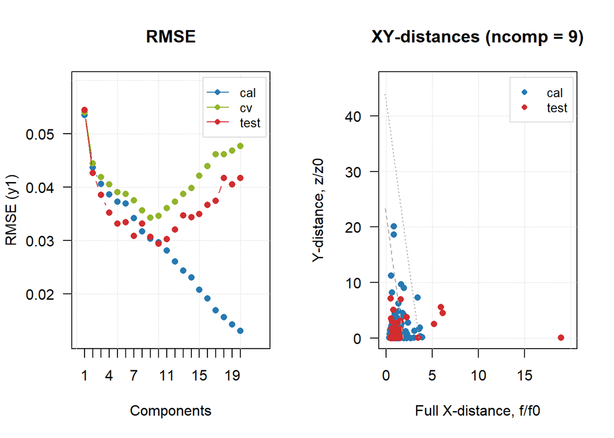

```r
par(mfrow = c(1, 2))
plotRMSE(m)
plotXYResiduals(m)
```

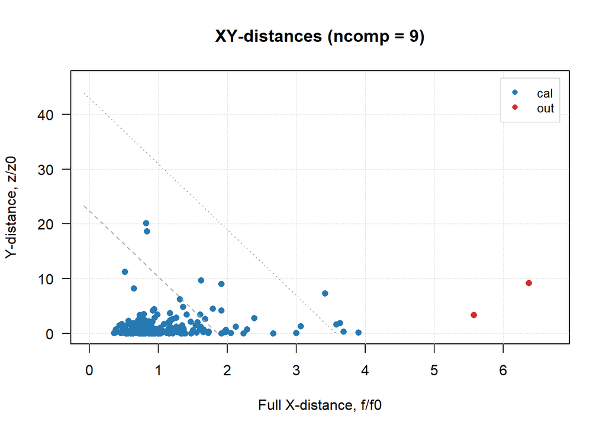

```r
res = predict(m, Xo, Yo)
plotXYResiduals(m, res = list("cal" = m$res$cal, "out" = res))
```